# Data Analytic task

```python
import pandas as pd
import matplotlib.pylab as plt
plt.style.use('ggplot')
import re
```

```python
data=pd.read_csv(r'C:\Users\femif\OneDrive\Documents\netflix_titles.csv[1]\netflix_titles.csv')
data
```

|  | show_id | type | title | director | cast | country | date_added | release_year | rating | duration | listed_in | description |
| --- | --- | --- | --- | --- | --- | --- | --- | --- | --- | --- | --- | --- |
| 0 | s1 | Movie | Dick Johnson Is Dead | Kirsten Johnson | NaN | United States | September 25, 2021 | 2020 | PG-13 | 90 min | Documentaries | As her father nears the end of his life, filmm... |
| 1 | s2 | TV Show | Blood & Water | NaN | Ama Qamata, Khosi Ngema, Gail Mabalane, Thaban... | South Africa | September 24, 2021 | 2021 | TV-MA | 2 Seasons | International TV Shows, TV Dramas, TV Mysteries | After crossing paths at a party, a Cape Town t... |
| 2 | s3 | TV Show | Ganglands | Julien Leclercq | Sami Bouajila, Tracy Gotoas, Samuel Jouy, Nabi... | NaN | September 24, 2021 | 2021 | TV-MA | 1 Season | Crime TV Shows, International TV Shows, TV Act... | To protect his family from a powerful drug lor... |
| 3 | s4 | TV Show | Jailbirds New Orleans | NaN | NaN | NaN | September 24, 2021 | 2021 | TV-MA | 1 Season | Docuseries, Reality TV | Feuds, flirtations and toilet talk go down amo... |
| 4 | s5 | TV Show | Kota Factory | NaN | Mayur More, Jitendra Kumar, Ranjan Raj, Alam K... | India | September 24, 2021 | 2021 | TV-MA | 2 Seasons | International TV Shows, Romantic TV Shows, TV ... | In a city of coaching centers known to train I... |
| ... | ... | ... | ... | ... | ... | ... | ... | ... | ... | ... | ... | ... |
| 8802 | s8803 | Movie | Zodiac | David Fincher | Mark Ruffalo, Jake Gyllenhaal, Robert Downey J... | United States | November 20, 2019 | 2007 | R | 158 min | Cult Movies, Dramas, Thrillers | A political cartoonist, a crime reporter and a... |
| 8803 | s8804 | TV Show | Zombie Dumb | NaN | NaN | NaN | July 1, 2019 | 2018 | TV-Y7 | 2 Seasons | Kids' TV, Korean TV Shows, TV Comedies | While living alone in a spooky town, a young g... |
| 8804 | s8805 | Movie | Zombieland | Ruben Fleischer | Jesse Eisenberg, Woody Harrelson, Emma Stone, ... | United States | November 1, 2019 | 2009 | R | 88 min | Comedies, Horror Movies | Looking to survive in a world taken over by zo... |
| 8805 | s8806 | Movie | Zoom | Peter Hewitt | Tim Allen, Courteney Cox, Chevy Chase, Kate Ma... | United States | January 11, 2020 | 2006 | PG | 88 min | Children & Family Movies, Comedies | Dragged from civilian life, a former superhero... |
| 8806 | s8807 | Movie | Zubaan | Mozez Singh | Vicky Kaushal, Sarah-Jane Dias, Raaghav Chanan... | India | March 2, 2019 | 2015 | TV-14 | 111 min | Dramas, International Movies, Music & Musicals | A scrappy but poor boy worms his way into a ty... |

8807 rows × 12 columns

1.Does Netflix has more focus on TV Shows than movies in recent years?

```python
a=data['type'].value_counts()
a
```

```
Movie      6131
TV Show    2676
Name: type, dtype: int64
```

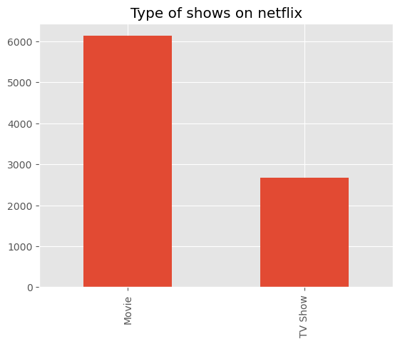

```python
data['type'].value_counts().plot(kind='bar',title= 'Type of shows on netflix')
```

1. Extract the top 10 directors by number of movies made from the dataset.

```python
data.loc[data['type']=='Movie', 'director'].value_counts().reset_index().head(10)
```

|  | index | director |
| --- | --- | --- |
| 0 | Rajiv Chilaka | 19 |
| 1 | Raúl Campos, Jan Suter | 18 |
| 2 | Suhas Kadav | 16 |
| 3 | Marcus Raboy | 15 |
| 4 | Jay Karas | 14 |
| 5 | Cathy Garcia-Molina | 13 |
| 6 | Martin Scorsese | 12 |
| 7 | Youssef Chahine | 12 |
| 8 | Jay Chapman | 12 |
| 9 | Steven Spielberg | 11 |

3.How many unique countries have produced movies?

```python
data.loc[data['type']=='Movie','country'].nunique()
```

```
651
```

```python
data['country'].value_counts()
```

```
United States                             2818
India                                      972
United Kingdom                             419
Japan                                      245
South Korea                                199
                                          ...
Romania, Bulgaria, Hungary                   1
Uruguay, Guatemala                           1
France, Senegal, Belgium                     1
Mexico, United States, Spain, Colombia       1
United Arab Emirates, Jordan                 1
Name: country, Length: 748, dtype: int64
```

4.In what year were the least movies produced?

```python
data.loc[data['type'] == 'Movie','release_year'].value_counts()
```

```
2017    767
2018    767
2016    658
2019    633
2020    517
       ...
1966      1
1961      1
1946      1
1963      1
1947      1
Name: release_year, Length: 73, dtype: int64
```

1. What is the tv show with maximum duration/seasons?

```python
data.loc[data['type']=='TV Show','duration'].value_counts()
```

```
1 Season      1793
2 Seasons      425
3 Seasons      199
4 Seasons       95
5 Seasons       65
6 Seasons       33
7 Seasons       23
8 Seasons       17
9 Seasons        9
10 Seasons       7
13 Seasons       3
15 Seasons       2
12 Seasons       2
11 Seasons       2
17 Seasons       1
Name: duration, dtype: int64
```

```python
data.loc[data['duration'] == '17 Seasons', :]
```

|  | show_id | type | title | director | cast | country | date_added | release_year | rating | duration | listed_in | description |
| --- | --- | --- | --- | --- | --- | --- | --- | --- | --- | --- | --- | --- |
| 548 | s549 | TV Show | Grey's Anatomy | NaN | Ellen Pompeo, Sandra Oh, Katherine Heigl, Just... | United States | July 3, 2021 | 2020 | TV-14 | 17 Seasons | Romantic TV Shows, TV Dramas | Intern (and eventual resident) Meredith Grey f... |

Grey's Anatomy has the maximum seasons released among all the TV shows available on netflix.

1. How many movies were produced in the last 10 years?

```python
data.loc[(data['type'] == 'Movie') & (data['release_year'] > 2013)].shape[0]
```

```
4281
```

1. Which countries produced the most movies?¶

```python
data.loc[data['type']=='Movie','country'].value_counts()
```

```
United States                            2058
India                                     893
United Kingdom                            206
Canada                                    122
Spain                                      97
                                         ...
United Kingdom, Russia, United States       1
Paraguay, Argentina                         1
United Kingdom, Malawi                      1
Austria, Iraq, United States                1
United Arab Emirates, Jordan                1
Name: country, Length: 651, dtype: int64
```

united states is produced the most number of movies

1. What is the most popular rating in TV shows?

```python
data.loc[data['type']=='TV Show','rating'].value_counts()
```

```
TV-MA       1145
TV-14        733
TV-PG        323
TV-Y7        195
TV-Y         176
TV-G          94
NR             5
R              2
TV-Y7-FV       1
Name: rating, dtype: int64
```

TV-MA is the most popular tv show

1. In which year were the most Adult rated movies produced?

```python
movie_rating = data.loc[(data['type'] == 'Movie') & (data['rating'] == 'TV-MA')]
```

```python
movie_rating.loc[:,'release_year'].value_counts()
```

```
2018    358
2017    337
2019    286
2016    273
2020    220
2015    135
2021    110
2014     62
2013     48
2012     41
2010     33
2008     20
2011     20
2006     13
2007     12
```

[output cut: 36 more lines]

2018 is the most movie producd

1. Who is the most popular movie director from India?

```python
a= data.loc[(data['country'] == 'India') & (data['type'] == 'Movie')]
```

```python
a.loc[: , 'director'].value_counts()
```

[output not shown]

[output cut: 74 more lines]

[output not shown]

1. Which movie is the smallest movie ever made?

```python
data.loc[(data['type'] == 'Movie') & (data['duration'] == '8 min')]
```

|  | show_id | type | title | director | cast | country | date_added | release_year | rating | duration | listed_in | description |
| --- | --- | --- | --- | --- | --- | --- | --- | --- | --- | --- | --- | --- |
| 1484 | s1485 | Movie | Cops and Robbers | Arnon Manor, Timothy Ware-Hill | Timothy Ware-Hill | United States | December 28, 2020 | 2020 | PG-13 | 8 min | Dramas | Animation and activism unite in this multimedi... |

1. Did 2020 see any new TV shows being released? True/False?

```python
release_2020 = data.loc[(data['type'] == 'TV Show') & (data['release_year'] == 2020)]
release_2020['type'].value_counts()
```

```
TV Show    436
Name: type, dtype: int64
```

1. How many categories of ratings exist?

```python
data.loc[:, 'rating'].nunique()
```

```
17
```

there are 17 types of ratings among TV show and Movies together exist on Netflix.

# 14. Does United States make more movies or tv shows?

```python
data.loc[(data['country']=='United States') & (data['type']=='TV Show'),'title'].nunique()
```

```
760
```

```python
data.loc[(data['country'] == 'United States') & (data['type'] == 'Movie'), 'title'].nunique()
```

```
2058
```

```python
# alternate approach
data.loc[(data['country'] == 'United States'), 'type'].value_counts()
```

```
Movie      2058
TV Show     760
Name: type, dtype: int64
```

US makes more movies than TV shows.

# 15. Does United States make lengthier movies than India?

```python
data['duration_int'] = data['duration'].str.extract(r'(\d+)')
data['duration_int'] = data['duration_int'].fillna(0).astype(int)
data
```

|  | show_id | type | title | director | cast | country | date_added | release_year | rating | duration | listed_in | description | duration_int |
| --- | --- | --- | --- | --- | --- | --- | --- | --- | --- | --- | --- | --- | --- |
| 0 | s1 | Movie | Dick Johnson Is Dead | Kirsten Johnson | NaN | United States | September 25, 2021 | 2020 | PG-13 | 90 min | Documentaries | As her father nears the end of his life, filmm... | 90 |
| 1 | s2 | TV Show | Blood & Water | NaN | Ama Qamata, Khosi Ngema, Gail Mabalane, Thaban... | South Africa | September 24, 2021 | 2021 | TV-MA | 2 Seasons | International TV Shows, TV Dramas, TV Mysteries | After crossing paths at a party, a Cape Town t... | 2 |
| 2 | s3 | TV Show | Ganglands | Julien Leclercq | Sami Bouajila, Tracy Gotoas, Samuel Jouy, Nabi... | NaN | September 24, 2021 | 2021 | TV-MA | 1 Season | Crime TV Shows, International TV Shows, TV Act... | To protect his family from a powerful drug lor... | 1 |
| 3 | s4 | TV Show | Jailbirds New Orleans | NaN | NaN | NaN | September 24, 2021 | 2021 | TV-MA | 1 Season | Docuseries, Reality TV | Feuds, flirtations and toilet talk go down amo... | 1 |
| 4 | s5 | TV Show | Kota Factory | NaN | Mayur More, Jitendra Kumar, Ranjan Raj, Alam K... | India | September 24, 2021 | 2021 | TV-MA | 2 Seasons | International TV Shows, Romantic TV Shows, TV ... | In a city of coaching centers known to train I... | 2 |
| ... | ... | ... | ... | ... | ... | ... | ... | ... | ... | ... | ... | ... | ... |
| 8802 | s8803 | Movie | Zodiac | David Fincher | Mark Ruffalo, Jake Gyllenhaal, Robert Downey J... | United States | November 20, 2019 | 2007 | R | 158 min | Cult Movies, Dramas, Thrillers | A political cartoonist, a crime reporter and a... | 158 |
| 8803 | s8804 | TV Show | Zombie Dumb | NaN | NaN | NaN | July 1, 2019 | 2018 | TV-Y7 | 2 Seasons | Kids' TV, Korean TV Shows, TV Comedies | While living alone in a spooky town, a young g... | 2 |
| 8804 | s8805 | Movie | Zombieland | Ruben Fleischer | Jesse Eisenberg, Woody Harrelson, Emma Stone, ... | United States | November 1, 2019 | 2009 | R | 88 min | Comedies, Horror Movies | Looking to survive in a world taken over by zo... | 88 |
| 8805 | s8806 | Movie | Zoom | Peter Hewitt | Tim Allen, Courteney Cox, Chevy Chase, Kate Ma... | United States | January 11, 2020 | 2006 | PG | 88 min | Children & Family Movies, Comedies | Dragged from civilian life, a former superhero... | 88 |
| 8806 | s8807 | Movie | Zubaan | Mozez Singh | Vicky Kaushal, Sarah-Jane Dias, Raaghav Chanan... | India | March 2, 2019 | 2015 | TV-14 | 111 min | Dramas, International Movies, Music & Musicals | A scrappy but poor boy worms his way into a ty... | 111 |

8807 rows × 13 columns

```python
data_movies = data[['type', 'country', 'duration_int']].query("type == 'Movie' and country in ('United States', 'India')")
data_movies.head()
```

|  | type | country | duration_int |
| --- | --- | --- | --- |
| 0 | Movie | United States | 90 |
| 9 | Movie | United States | 104 |
| 24 | Movie | India | 166 |
| 27 | Movie | United States | 103 |
| 28 | Movie | United States | 97 |

```python
data_movies.groupby('country')['duration_int'].mean()
```

```
country
India            126.922732
United States     90.497570
Name: duration_int, dtype: float64
```

India makes lenthier movies than Unites States make.

# 16. Was there a tv/show that was released on Feb 29 of any year?

```python
data.loc[data['date_added']=='February 29']
```

|  | show_id | type | title | director | cast | country | date_added | release_year | rating | duration | listed_in | description | duration_int |
| --- | --- | --- | --- | --- | --- | --- | --- | --- | --- | --- | --- | --- | --- |

# 17. Which directors produced atleast one movie in 2021?

```python
release_year = data.loc[(data['type'] == 'Movie') & (data['release_year'] == 2021)]
pd.DataFrame(release_year.loc[:, 'director']).value_counts()
```

```
director
Rathindran R Prasad    4
Leigh Janiak           3
Troy Miller            2
Ben Simms              2
Keishi Otomo           2
                      ..
Hemambar Jasti         1
Ivan Ayr               1
J Blakeson             1
Jakub Piątek           1
Zhao Ji                1
Length: 241, dtype: int64
```

# 18. How many unique TV shows and movies are there in the dataset?

```python
data.groupby('type').nunique().loc[:, 'title']
```

```
type
Movie      6131
TV Show    2676
Name: title, dtype: int64
```

# 19. How many TV shows and movies are there per country?

```python
data.groupby(['country', 'type']).nunique().loc[:, 'title']
```

```
country                                              type
, France, Algeria                                    Movie       1
, South Korea                                        TV Show     1
Argentina                                            Movie      38
                                                     TV Show    18
Argentina, Brazil, France, Poland, Germany, Denmark  Movie       1
                                                                ..
Venezuela                                            Movie       1
Venezuela, Colombia                                  Movie       1
Vietnam                                              Movie       7
West Germany                                         Movie       1
Zimbabwe                                             Movie       1
Name: title, Length: 847, dtype: int64
```

# 20. What is the average duration of a movie in the dataset?

```python
data['duration_int'] = data['duration'].str.extract(r'(\d+)')
data['duration_int'] = data['duration_int'].fillna(0).astype(int)
data.loc[data['type'] == 'Movie','duration_int'].mean()
```

```
99.52846191485891
```

# 21. How many movies and TV shows were added to Netflix each year?

```python
data.groupby(['type', 'release_year']).nunique().loc[:, 'title']
```

```
type     release_year
Movie    1942              2
         1943              3
         1944              3
         1945              3
         1946              1
                        ...
TV Show  2017            265
         2018            380
         2019            397
         2020            436
         2021            315
Name: title, Length: 119, dtype: int64
```

# 22. What is the most common rating for movies and TV shows in the dataset?

```python
data_agg = data.groupby(['type', 'rating'])['title'].nunique().reset_index()
data_agg.query("type == 'Movie'").nlargest(n=1, columns='title')
```

|  | type | rating | title |
| --- | --- | --- | --- |
| 11 | Movie | TV-MA | 2062 |

```python
data_agg.query("type == 'TV Show'").nlargest(n=1, columns='title')
```

|  | type | rating | title |
| --- | --- | --- | --- |
| 21 | TV Show | TV-MA | 1145 |

# 23. What is the average duration of movies released each year?

```python
data['duration_int'] = data['duration'].str.extract(r'(\d+)')
data['duration_int'] = data['duration_int'].fillna(0).astype(int)
movie_yearwise = data.loc[(data['type'] == 'Movie')]
movie_yearwise = movie_yearwise.groupby(['release_year'])['duration_int'].mean().reset_index()
movie_yearwise
```

|  | release_year | duration_int |
| --- | --- | --- |
| 0 | 1942 | 35.000000 |
| 1 | 1943 | 62.666667 |
| 2 | 1944 | 52.000000 |
| 3 | 1945 | 51.333333 |
| 4 | 1946 | 58.000000 |
| ... | ... | ... |
| 68 | 2017 | 95.410691 |
| 69 | 2018 | 96.185137 |
| 70 | 2019 | 93.466035 |
| 71 | 2020 | 92.141199 |
| 72 | 2021 | 96.444043 |

73 rows × 2 columns

# 25. Which country has produced the most number of movies?

```python
num_movie = data.loc[(data['type'] == 'Movie')]
num_movie = num_movie.groupby(['country'])['title'].count().sort_values(ascending=False)
num_movie
```

```
country
United States      2058
India               893
United Kingdom      206
Canada              122
Spain                97
                   ...
India, Mexico         1
India, Malaysia       1
India, Japan          1
India, Iran           1
Zimbabwe              1
Name: title, Length: 651, dtype: int64
```

# 26. Which country has produced the most number of TV shows?

```python
num_tvshow = data.loc[(data['type'] == 'TV Show')]
num_tvshow = num_tvshow.groupby('country')['title'].count().sort_values(ascending=False)
num_tvshow
```

```
country
United States                                                  760
United Kingdom                                                 213
Japan                                                          169
South Korea                                                    158
India                                                           79
                                                              ...
Italy, Canada, France                                            1
Italy, Germany                                                   1
Italy, South Africa, West Germany, Australia, United States      1
Italy, United Kingdom                                            1
Uruguay, Germany                                                 1
Name: title, Length: 196, dtype: int64
```

# 27. What is the earliest and latest release year in the dataset?

```python
data.loc[:, 'release_year'].sort_values().reset_index()
```

|  | index | release_year |
| --- | --- | --- |
| 0 | 4250 | 1925 |
| 1 | 7790 | 1942 |
| 2 | 8205 | 1942 |
| 3 | 8660 | 1943 |
| 4 | 8739 | 1943 |
| ... | ... | ... |
| 8802 | 862 | 2021 |
| 8803 | 861 | 2021 |
| 8804 | 857 | 2021 |
| 8805 | 876 | 2021 |
| 8806 | 965 | 2021 |

8807 rows × 2 columns

```python
data.head()
```

|  | show_id | type | title | director | cast | country | date_added | release_year | rating | duration | listed_in | description | duration_int |
| --- | --- | --- | --- | --- | --- | --- | --- | --- | --- | --- | --- | --- | --- |
| 0 | s1 | Movie | Dick Johnson Is Dead | Kirsten Johnson | NaN | United States | September 25, 2021 | 2020 | PG-13 | 90 min | Documentaries | As her father nears the end of his life, filmm... | 90 |
| 1 | s2 | TV Show | Blood & Water | NaN | Ama Qamata, Khosi Ngema, Gail Mabalane, Thaban... | South Africa | September 24, 2021 | 2021 | TV-MA | 2 Seasons | International TV Shows, TV Dramas, TV Mysteries | After crossing paths at a party, a Cape Town t... | 2 |
| 2 | s3 | TV Show | Ganglands | Julien Leclercq | Sami Bouajila, Tracy Gotoas, Samuel Jouy, Nabi... | NaN | September 24, 2021 | 2021 | TV-MA | 1 Season | Crime TV Shows, International TV Shows, TV Act... | To protect his family from a powerful drug lor... | 1 |
| 3 | s4 | TV Show | Jailbirds New Orleans | NaN | NaN | NaN | September 24, 2021 | 2021 | TV-MA | 1 Season | Docuseries, Reality TV | Feuds, flirtations and toilet talk go down amo... | 1 |
| 4 | s5 | TV Show | Kota Factory | NaN | Mayur More, Jitendra Kumar, Ranjan Raj, Alam K... | India | September 24, 2021 | 2021 | TV-MA | 2 Seasons | International TV Shows, Romantic TV Shows, TV ... | In a city of coaching centers known to train I... | 2 |

# 29.What is the most common duration for movies in the dataset?

```python
movie_ds = data.loc[(data['type'] == 'Movie')]
movie_ds = movie_ds.groupby('duration')['title'].nunique().reset_index()
movie_ds = movie_ds.rename(columns={'title': 'number_of_titles'})
movie_ds.sort_values('number_of_titles', ascending=False)
```

|  | duration | number_of_titles |
| --- | --- | --- |
| 195 | 90 min | 152 |
| 198 | 93 min | 146 |
| 199 | 94 min | 146 |
| 202 | 97 min | 146 |
| 196 | 91 min | 144 |
| ... | ... | ... |
| 124 | 253 min | 1 |
| 127 | 273 min | 1 |
| 130 | 3 min | 1 |
| 133 | 312 min | 1 |
| 102 | 196 min | 1 |

205 rows × 2 columns

# 30. What is the most common number of seasons for TV shows in the dataset?

```python
b = data.loc[(data['type'] == 'TV Show')]
b.groupby('duration').nunique()
```

| duration | show_id | type | title | director | cast | country | date_added | release_year | rating | listed_in | description | duration_int |
| --- | --- | --- | --- | --- | --- | --- | --- | --- | --- | --- | --- | --- |
| 1 Season | 1793 | 1 | 1793 | 178 | 1476 | 139 | 811 | 41 | 8 | 186 | 1790 | 1 |
| 10 Seasons | 7 | 1 | 7 | 0 | 7 | 4 | 6 | 5 | 5 | 7 | 7 | 1 |
| 11 Seasons | 2 | 1 | 2 | 0 | 2 | 1 | 1 | 2 | 1 | 1 | 2 | 1 |
| 12 Seasons | 2 | 1 | 2 | 0 | 2 | 2 | 2 | 2 | 2 | 2 | 2 | 1 |
| 13 Seasons | 3 | 1 | 3 | 0 | 3 | 2 | 2 | 2 | 3 | 3 | 3 | 1 |
| 15 Seasons | 2 | 1 | 2 | 1 | 2 | 2 | 2 | 2 | 1 | 2 | 2 | 1 |
| 17 Seasons | 1 | 1 | 1 | 0 | 1 | 1 | 1 | 1 | 1 | 1 | 1 | 1 |
| 2 Seasons | 425 | 1 | 425 | 21 | 384 | 74 | 321 | 23 | 7 | 113 | 425 | 1 |
| 3 Seasons | 199 | 1 | 199 | 4 | 179 | 48 | 175 | 16 | 7 | 85 | 198 | 1 |
| 4 Seasons | 95 | 1 | 95 | 4 | 93 | 28 | 87 | 17 | 6 | 52 | 95 | 1 |
| 5 Seasons | 65 | 1 | 65 | 6 | 65 | 15 | 61 | 16 | 6 | 41 | 65 | 1 |
| 6 Seasons | 33 | 1 | 33 | 3 | 32 | 8 | 30 | 14 | 6 | 25 | 33 | 1 |
| 7 Seasons | 23 | 1 | 23 | 1 | 23 | 6 | 23 | 15 | 3 | 15 | 23 | 1 |
| 8 Seasons | 17 | 1 | 17 | 3 | 16 | 3 | 17 | 10 | 6 | 11 | 17 | 1 |
| 9 Seasons | 9 | 1 | 9 | 3 | 9 | 3 | 9 | 9 | 3 | 9 | 9 | 1 |

```python
data.query("title == 'Kota Factory'")
```

|  | show_id | type | title | director | cast | country | date_added | release_year | rating | duration | listed_in | description | duration_int |
| --- | --- | --- | --- | --- | --- | --- | --- | --- | --- | --- | --- | --- | --- |
| 4 | s5 | TV Show | Kota Factory | NaN | Mayur More, Jitendra Kumar, Ranjan Raj, Alam K... | India | September 24, 2021 | 2021 | TV-MA | 2 Seasons | International TV Shows, Romantic TV Shows, TV ... | In a city of coaching centers known to train I... | 2 |

# 31. How many unique directors are there in the dataset?

```python
data.groupby('director')['title'].nunique().count()
```

```
4528
```

# 32. What is the most common release year for movies and TV shows in the dataset?¶

```python
data.loc[data['type']=='Movie','release_year'].value_counts().head(5)
```

```
2017    767
2018    767
2016    658
2019    633
2020    517
Name: release_year, dtype: int64
```

```python
data.loc[data['type']=='TV Show','release_year'].value_counts().head(5)
```

```
2020    436
2019    397
2018    380
2021    315
2017    265
Name: release_year, dtype: int64
```

```python
data.groupby(['type', 'country'])['country'].value_counts()
```

```
type     country                                              country
Movie    , France, Algeria                                    , France, Algeria                                       1
         Argentina                                            Argentina                                              38
         Argentina, Brazil, France, Poland, Germany, Denmark  Argentina, Brazil, France, Poland, Germany, Denmark     1
         Argentina, Chile                                     Argentina, Chile                                        2
         Argentina, Chile, Peru                               Argentina, Chile, Peru                                  1
                                                                                                                     ..
TV Show  United States, South Korea, China                    United States, South Korea, China                       2
         United States, Sweden                                United States, Sweden                                   1
         United States, United Kingdom                        United States, United Kingdom                           9
         United States, United Kingdom, Australia             United States, United Kingdom, Australia                1
         Uruguay, Germany                                     Uruguay, Germany                                        1
Name: country, Length: 847, dtype: int64
```

```python
data.groupby(['type', 'country'])['country'].value_counts()
```

```
type     country                                              country
Movie    , France, Algeria                                    , France, Algeria                                       1
         Argentina                                            Argentina                                              38
         Argentina, Brazil, France, Poland, Germany, Denmark  Argentina, Brazil, France, Poland, Germany, Denmark     1
         Argentina, Chile                                     Argentina, Chile                                        2
         Argentina, Chile, Peru                               Argentina, Chile, Peru                                  1
                                                                                                                     ..
TV Show  United States, South Korea, China                    United States, South Korea, China                       2
         United States, Sweden                                United States, Sweden                                   1
         United States, United Kingdom                        United States, United Kingdom                           9
         United States, United Kingdom, Australia             United States, United Kingdom, Australia                1
         Uruguay, Germany                                     Uruguay, Germany                                        1
Name: country, Length: 847, dtype: int64
```

# 33. How many movies and TV shows were produced by each country per year?

```python
data.groupby(['type', 'country'])['country'].value_counts().reset_index()
```

[output not shown]

```python
data.loc[data['type']=='Movie','country'].value_counts().reset_index()
```

|  | index | country |
| --- | --- | --- |
| 0 | United States | 2058 |
| 1 | India | 893 |
| 2 | United Kingdom | 206 |
| 3 | Canada | 122 |
| 4 | Spain | 97 |
| ... | ... | ... |
| 646 | United Kingdom, Russia, United States | 1 |
| 647 | Paraguay, Argentina | 1 |
| 648 | United Kingdom, Malawi | 1 |
| 649 | Austria, Iraq, United States | 1 |
| 650 | United Arab Emirates, Jordan | 1 |

651 rows × 2 columns

```python
data.groupby(['type', 'country'])['country'].value_counts()
```

```
type     country                                              country
Movie    , France, Algeria                                    , France, Algeria                                       1
         Argentina                                            Argentina                                              38
         Argentina, Brazil, France, Poland, Germany, Denmark  Argentina, Brazil, France, Poland, Germany, Denmark     1
         Argentina, Chile                                     Argentina, Chile                                        2
         Argentina, Chile, Peru                               Argentina, Chile, Peru                                  1
                                                                                                                     ..
TV Show  United States, South Korea, China                    United States, South Korea, China                       2
         United States, Sweden                                United States, Sweden                                   1
         United States, United Kingdom                        United States, United Kingdom                           9
         United States, United Kingdom, Australia             United States, United Kingdom, Australia                1
         Uruguay, Germany                                     Uruguay, Germany                                        1
Name: country, Length: 847, dtype: int64
```

# 34. How many movies and TV shows does each rating category have per year?

```python
data.groupby(['type', 'rating'])['release_year'].value_counts()
```

```
type     rating    release_year
Movie    66 min    2015            1
         74 min    2017            1
         84 min    2010            1
         G         2009            4
                   2004            3
                                  ..
TV Show  TV-Y7     2001            1
                   2002            1
                   2004            1
                   2006            1
         TV-Y7-FV  2014            1
Name: release_year, Length: 564, dtype: int64
```

# 35. How many movies and TV shows were directed by each director per year?

```python
data_peryear = data.groupby(['type', 'director','release_year'])['title'].count().reset_index()
data_peryear
```

|  | type | director | release_year | title |
| --- | --- | --- | --- | --- |
| 0 | Movie | A. L. Vijay | 2016 | 1 |
| 1 | Movie | A. L. Vijay | 2019 | 1 |
| 2 | Movie | A. Raajdheep | 2020 | 1 |
| 3 | Movie | A. Salaam | 1975 | 1 |
| 4 | Movie | A.R. Murugadoss | 2017 | 1 |
| ... | ... | ... | ... | ... |
| 5906 | TV Show | Vijay S. Bhanushali | 2019 | 1 |
| 5907 | TV Show | Vikramaditya Motwane, Anurag Kashyap | 2019 | 1 |
| 5908 | TV Show | Wouter Bouvijn | 2019 | 1 |
| 5909 | TV Show | Yasuhiro Irie | 2010 | 1 |
| 5910 | TV Show | Ziad Doueiri | 2020 | 1 |

5911 rows × 4 columns